# Predicting the Presence of Exoplanets for Kepler Objects of Interest

# Introduction

Extrosolar planets may be discovered by detecting their host stars as the planets pass in front of them. Potential such host stars are referred to as “Kepler objects of interest”. The data given to us contains information on a set of 9177 Kepler objects of interest, with 18 predictor variables that measure aspects related to exoplanets, host stars, exoplanet orbits, and transit, and a response variable that states for each observation if we have identified a confirmed exoplanet (“CONFIRMED”), have not identified an exoplanet (“FALSE POSITIVE”), or are unsure of the nature of what we have found (“CANDIDATE”). The descriptions of the predictors are given below:

```
##           Names
## 1    koi_period
## 2     koi_eccen
## 3    koi_impact
## 4  koi_duration
## 5     koi_depth
## 6       koi_ror
## 7      koi_srho
## 8      koi_prad
## 9       koi_sma
## 10     koi_incl
## 11      koi_teq
## 12    koi_insol
## 13      koi_dor
## 14    koi_steff
```

[output cut: 23 more lines]

Our aim is to identify a model that may be trained in order to effectively differentiate between “CONFIRMED” and “FALSE POSITIVE” exoplanetary candidates.

# Summary of given data

Firstly, looking at our dataset, it appears that koi_eccen has only zeroes in it, so we may remove this predictor as it will likely not contribute much to our analysis. Next, we must remove the rows which have a response of “CANDIDATE” from our dataset as we are only interested in predicting our responses as either “CONFIRMED” or “FALSE POSITIVE”. We will also split our data into test and training sets, keeping 80% of the data in our training set and the other portion in our test set.

```r
set.seed(101)
df$koi_eccen = NULL
predictors$koi_eccen = NULL
response = droplevels(response, "CANDIDATE")
indices.resp = which(response== "CONFIRMED" | response== "FALSE POSITIVE")
response = response[indices.resp]
rm.indices = which(df$y == "CANDIDATE")
df.candidate = df[rm.indices,]
pred.main = predictors
resp.main = response
df.main = df
df = df[-rm.indices,]
predictors = predictors[-rm.indices,]
indices = sample(c(1:nrow(predictors)),0.8*nrow(predictors))
pred.train = predictors[indices,]
resp.train = response[indices]
resp.test = response[-indices]
pred.test = predictors[-indices,]
```

Next, we will conduct a summary of our dataset.

```
##    koi_period          koi_impact        koi_duration
##  Min.   :   0.2418   Min.   :  0.0000   Min.   :  0.1046
##  1st Qu.:   2.1132   1st Qu.:  0.2330   1st Qu.:  2.5379
##  Median :   7.4427   Median :  0.5920   Median :  3.9085
##  Mean   :  50.8026   Mean   :  0.7632   Mean   :  5.8514
##  3rd Qu.:  27.5014   3rd Qu.:  0.9220   3rd Qu.:  6.3490
##  Max.   :1071.2326   Max.   :100.8060   Max.   :138.5400
##    koi_depth            koi_ror            koi_srho
##  Min.   :      0.8   Min.   : 0.00129   Min.   :  0.0000
##  1st Qu.:    181.9   1st Qu.: 0.01320   1st Qu.:  0.1777
##  Median :    512.6   Median : 0.02453   Median :  0.7595
##  Mean   :  31492.3   Mean   : 0.30180   Mean   :  6.9371
##  3rd Qu.:   3031.6   3rd Qu.: 0.21976   3rd Qu.:  2.3885
##  Max.   :1541400.0   Max.   :99.87065   Max.   :980.8542
##     koi_prad            koi_sma          koi_incl        koi_teq
##  Min.   :     0.08   Min.   :0.0059   Min.   : 2.29   Min.   :   92.0
##  1st Qu.:     1.51   1st Qu.:0.0320   1st Qu.:81.37   1st Qu.:  583.5
##  Median :     2.71   Median :0.0741   Median :87.89   Median :  955.0
##  Mean   :   109.93   Mean   :0.1919   Mean   :80.81   Mean   : 1177.7
##  3rd Qu.:    26.82   3rd Qu.:0.1763   3rd Qu.:89.62   3rd Qu.: 1531.0
##  Max.   :200346.00   Max.   :2.1525   Max.   :90.00   Max.   :14667.0
##    koi_insol           koi_dor           koi_steff       koi_slogg
##  Min.   :       0   Min.   :   0.386   Min.   : 2661   Min.   :0.047
##  1st Qu.:      27   1st Qu.:   4.053   1st Qu.: 5325   1st Qu.:4.204
##  Median :     197   Median :  12.220   Median : 5780   Median :4.438
##  Mean   :    9897   Mean   :  55.334   Mean   : 5730   Mean   :4.304
##  3rd Qu.:    1298   3rd Qu.:  34.700   3rd Qu.: 6130   3rd Qu.:4.542
##  Max.   :10947555   Max.   :2421.700   Max.   :15896   Max.   :5.283
##     koi_smet          koi_srad         koi_smass                  y
##  Min.   :-2.5000   Min.   :  0.116   Min.   :0.094   CANDIDATE     :   0
##  1st Qu.:-0.2800   1st Qu.:  0.830   1st Qu.:0.844   CONFIRMED     :2296
##  Median :-0.1000   Median :  1.000   Median :0.974   FALSE POSITIVE:4563
##  Mean   :-0.1357   Mean   :  1.775   Mean   :1.029
##  3rd Qu.: 0.0600   3rd Qu.:  1.368   3rd Qu.:1.104
##  Max.   : 0.5600   Max.   :229.908   Max.   :3.686
```

Upon looking at the summary of the given data, we notice that there are significant differences between the mean and median values (with higher mean than median values) for the koi_period, koi_depth, koi_srho, koi_prad, koi_insol, koi_sma and koi_dor variables, indicating right skewness in the distribution for these variables. There also appear to be strong outliers for many of the variables (such as koi_period, koi_prad and koi_depth), indicated by the large differences between the maximum and third quartile values for these variables. The data for variables such as koi_smass, koi_steff and koi_slogg hints at symmetric distributions, shown by the closeness between their mean and median values.

# Distributions of variables

Upon conducting our initial visualization, it was noticed that many of our predictor variables were significantly skewed. To ensure that our analysis is smoother, we may transform our right-skewed variables using log transformations. In the case of koi_incl which was left-skewed, we may use a cube transformation.

```r
predictors$koi_period = log(predictors$koi_period)
predictors$koi_depth = log(predictors$koi_depth)
predictors$koi_srho = log(predictors$koi_srho)
predictors$koi_prad = log(predictors$koi_prad)
predictors$koi_insol = log(predictors$koi_insol)
predictors$koi_dor = log(predictors$koi_dor)
predictors$koi_sma = log(predictors$koi_sma)
predictors$koi_incl = (predictors$koi_incl)^(3)
df = data.frame(predictors,"y"=response)
```

## Orbit-related variables

We may begin by creating diagrams to observe the distribution of our variables. To start with, we will look at orbit-related variables.

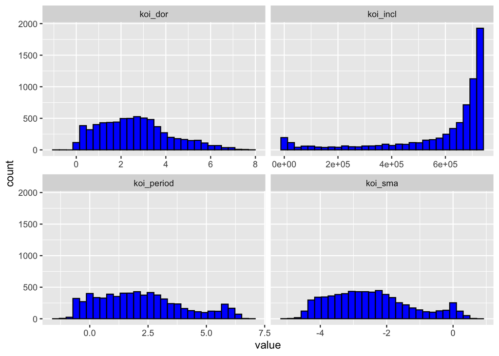

Koi_dor, koi_period and koi_sma appear to have roughly symmetric distributions, while the distribution of koi_incl still appears to be significantly left-skewed.

## Transit/eclipse-related variables

Next, we may look at the distributions for the transit/eclipse-related variables, namely, koi_impact, koi_duration, and koi_depth. Focusing on koi_depth, we observe a roughly symmetric (and perhaps bimodal) distribution.

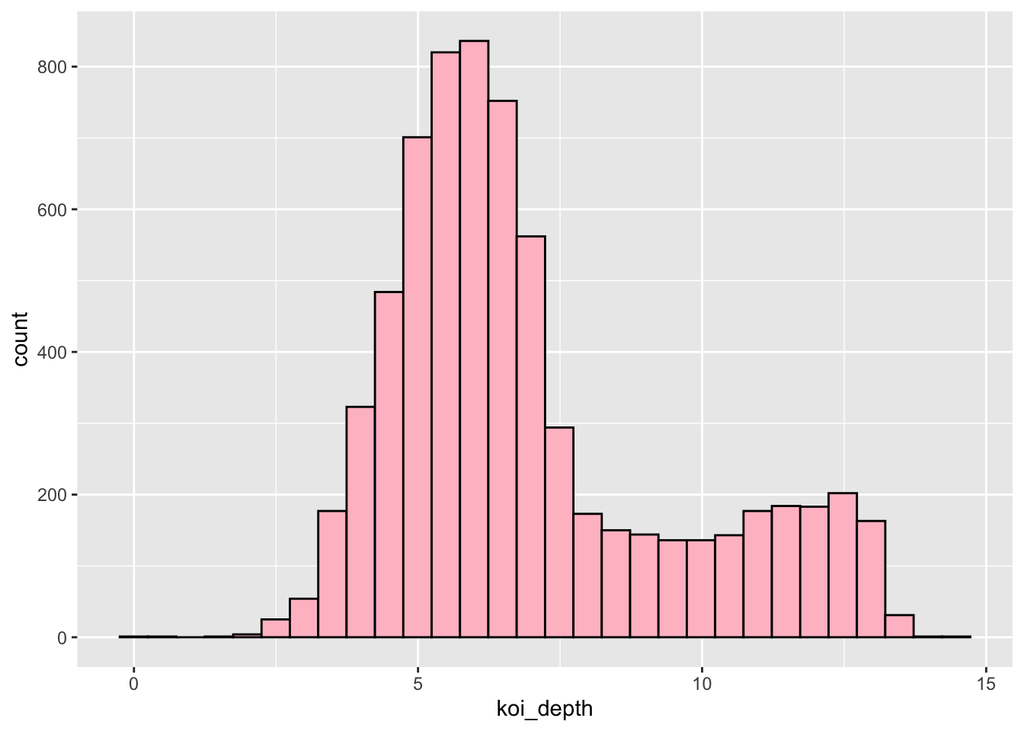

## Exoplanet property-related variables

Next, we may take a look at the exoplanet property-related variables, which are koi_ror, koi_prad, koi_teq and koi_insol. Focusing on koi_insol and koi_prad, we observe the following:

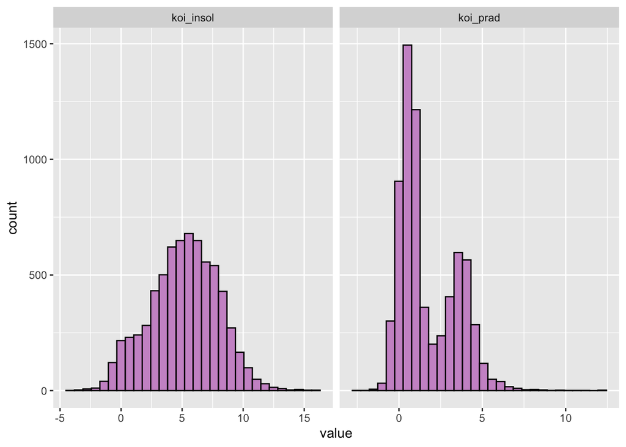

The distribution of koi_insol appears to be fairly symmetric and unimodal, while that for koi_prad appears to be somewhat symmetric and bimodal.

## Host star property-related variables

Finally, we may look at the distributions for the host star property-related variables (koi_srho, koi_steff, koi_slogg, koi_smet, koi_srad and koi_smass). Focusing on koi_srho, we observe the following:

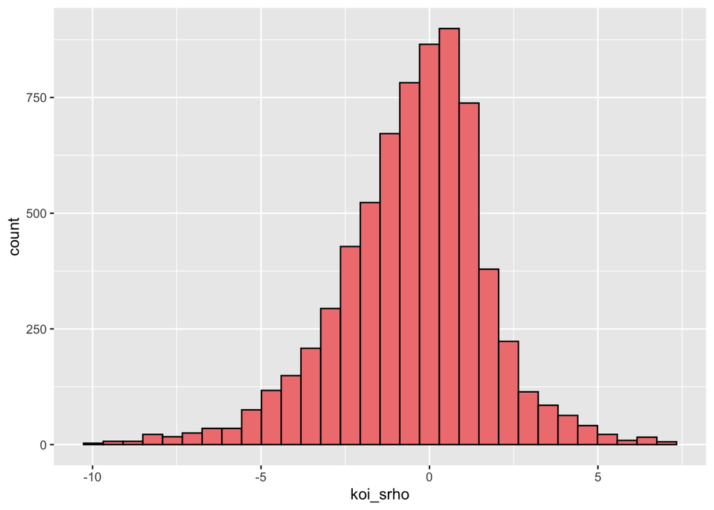

Our histogram indicates that koi_srho has a fairly symmetric and unimodal distribution, with the mode situated at roughly 0.

# Examining relationships between variables

Before going on to conduct principal components analysis, it is useful to identify if any of the variables are strongly correlated with one another so as to reduce our number of predictors. We can examine this by constructing a correlation plot for our data as shown below.

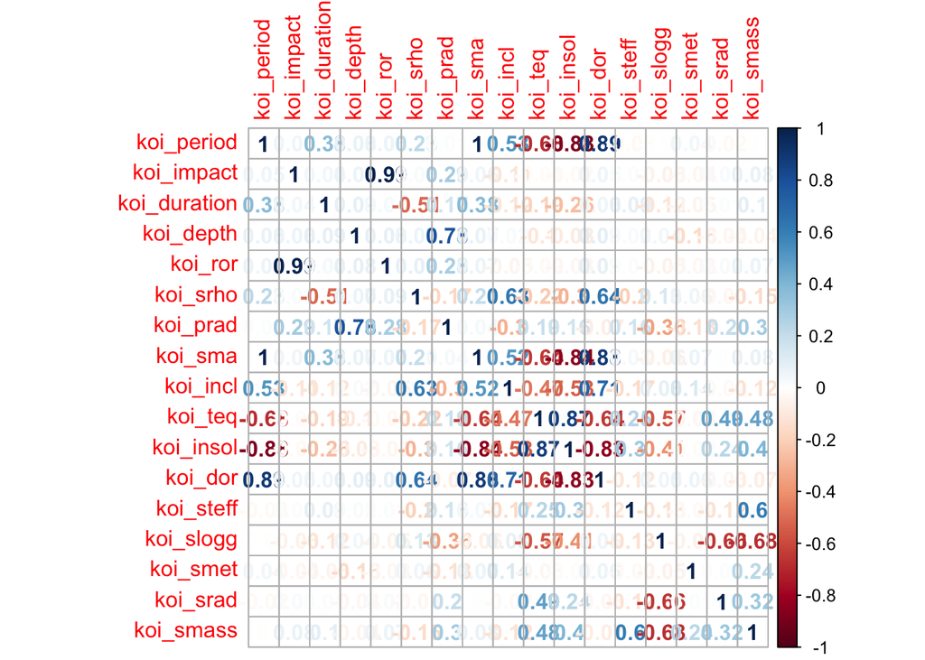

As shown by the correlation plot above, there appear to be especially strong positive correlations between koi_impact and koi_ror, koi_sma and koi_period, and fairly strong positive correlations between koi_dor and koi_period, koi_sma and koi_dor, and koi_insol and koi_teq. There also appear to be fairly strong negative correlations between koi_period and koi_insol, koi_insol and koi_sma, as well as between koi_insol and koi_dor.

We will observe the relationships between koi_impact and koi_ror, and between koi_sma and koi_period (as the positive correlation values between these variables were especially high), as well as the negative relationship between koi_period and koi_insol.

## Koi_ror vs. Koi_impact

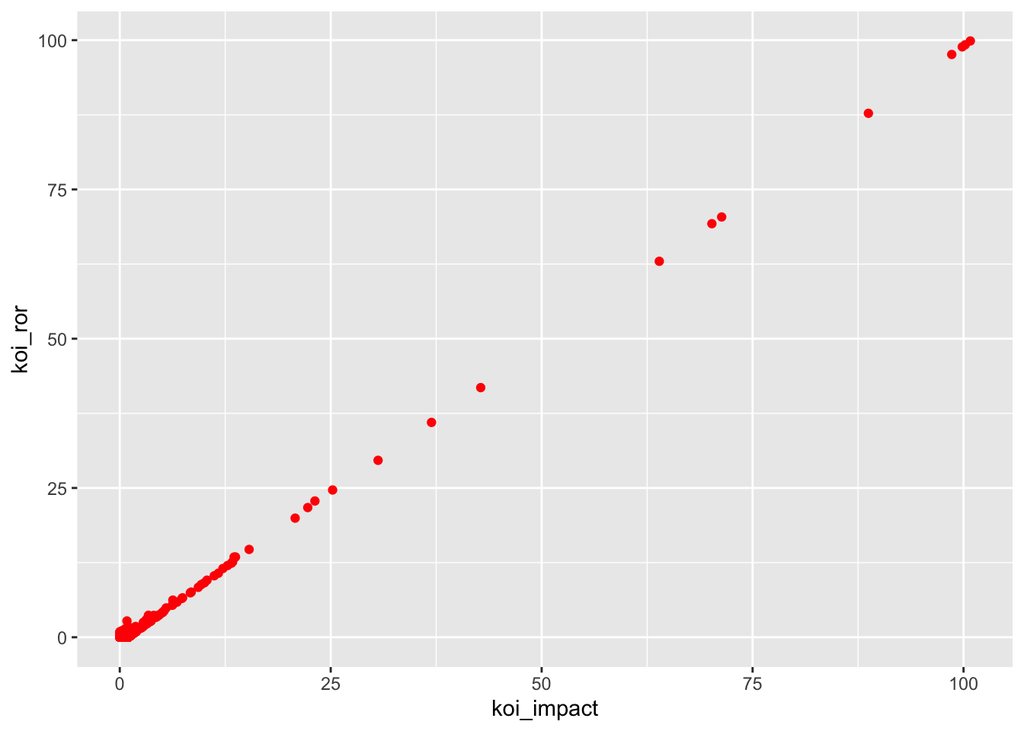

As shown by the scatterplot above, there appears to be a very strong positive relationship between koi_impact and koi_ror, with most of the data points occuring between 0 and around 12 (on both the y and x-axes). The relationship here appears to be rather deterministic, so it would be good for our analysis to remove one of the variables.

## Koi_period vs. Koi_sma

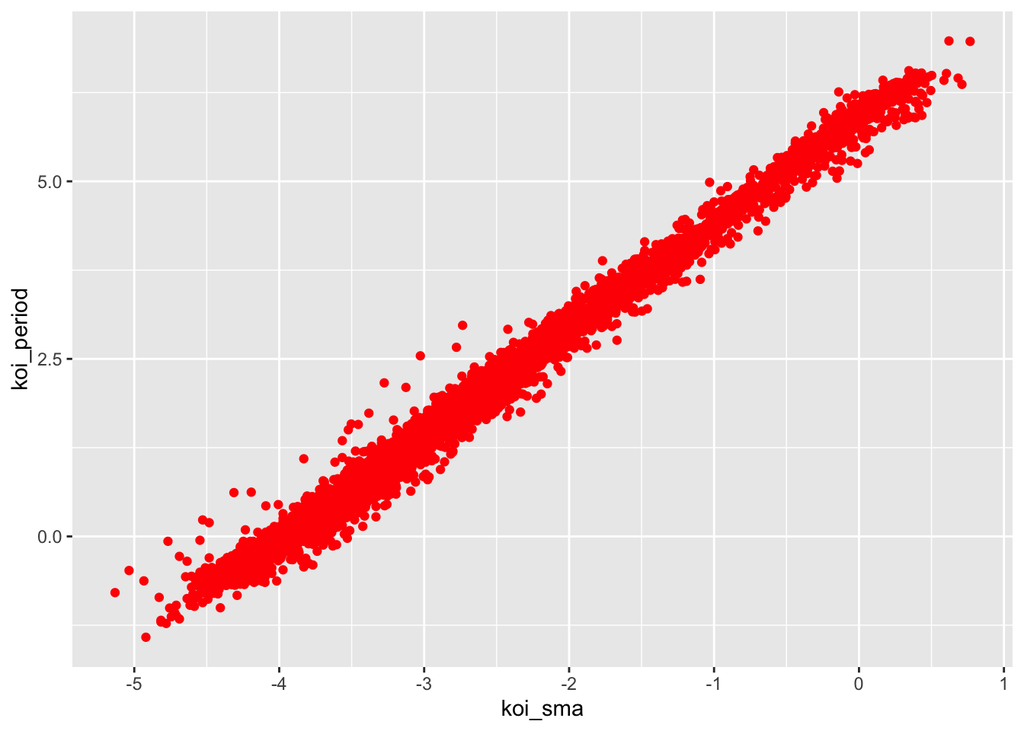

The scatterplot shown above suggests a strong positive linear relationship between the two variables, with values becoming slightly less clustered and koi_sma and koi_period increase. This relationship also appears to be somewhat deterministic, so we may remove one of the variables from our dataset.

## Koi_insol vs. Koi_period

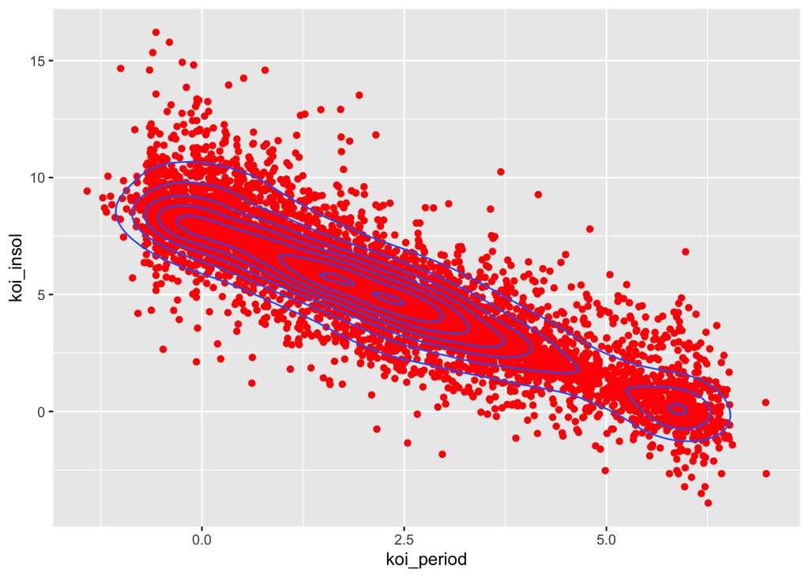

There appears to be a fairly strong negative relationship between koi_period and koi_insol.

Because of the very high correlation values between koi_impact and koi_ror and the rather deterministic relationship between the two, we will remove koi_ror. We will also remove koi_sma due to the deterministic relationship between koi_sma and koi_period.

```r
df = df[,-c(5,8)]
predictors = predictors[,-c(5,8)]
pred.train = pred.train[,-c(5,8)]
pred.test = pred.test[,-c(5,8)]
```

# PC Analysis

Given that we have a large number of variables in our dataset, conducting PCA would give us an idea of whether we could reduce the dimensionality of our predictor space.

```r
pr.out = prcomp(predictors, scale = TRUE)
```

PC1 appears to be most strongly tied to koi_insol, PC2 to koi_slogg, PC3 to koi_srho, PC4 to koi_depth, PC5 to koi_steff, PC6 to koi_impact, PC7 to koi_smet, PC8 to koi_incl, PC9 to koi_srad, PC10 to koi_srho, PC11 to koi_smass, PC12 to koi_teq, PC13 to koi_prad, PC14 to koi_insol, and PC15 to koi_dor.

We may now construct a plot to observe the cumulative proportions of variance explained by our 15 principal components, so as to determine which ones we must retain:

[figure not shown]

```
## Importance of components:
##                           PC1    PC2    PC3    PC4     PC5     PC6     PC7
## Standard deviation     2.1363 1.5624 1.4116 1.2625 1.12427 0.99030 0.95666
## Proportion of Variance 0.3043 0.1628 0.1328 0.1063 0.08427 0.06538 0.06101
## Cumulative Proportion  0.3043 0.4670 0.5998 0.7061 0.79038 0.85576 0.91677
##                           PC8     PC9    PC10    PC11    PC12   PC13
## Standard deviation     0.6245 0.57249 0.50426 0.36184 0.31040 0.2192
## Proportion of Variance 0.0260 0.02185 0.01695 0.00873 0.00642 0.0032
## Cumulative Proportion  0.9428 0.96462 0.98158 0.99030 0.99673 0.9999
##                           PC14      PC15
## Standard deviation     0.03207 0.0002105
## Proportion of Variance 0.00007 0.0000000
## Cumulative Proportion  1.00000 1.0000000
```

Now, we may create a new dataset with only our 7 retained principal components (which we will need when conducting logistic regression analysis).

```r
set.seed(101)
pca.pred.df = data.frame(predict(pr.out, predictors)[,1:7])
pca.pred.train = pca.pred.df[indices,]
pca.pred.test = pca.pred.df[-indices,]
pca.df = data.frame(pca.pred.df, response)
```

## Regression Analyses

We may now attempt to apply regression models to our data, and observe which ones provide us with the best fit (by identifying which ones yield the lowest misclassification rate). We will also note the area under the curve values for the ROC curves of each of our models.

### Logistic Regression

We can start with a logistic regression model:

```r
set.seed(101)
#Using our main training and test data
glm.out = glm(resp.train~., data = pred.train, family = binomial)
summary(glm.out)
```

```
##
## Call:
## glm(formula = resp.train ~ ., family = binomial, data = pred.train)
##
## Deviance Residuals:
##     Min       1Q   Median       3Q      Max
## -4.4112  -0.4996   0.0098   0.3219   2.9298
##
## Coefficients:
##                Estimate Std. Error z value Pr(>|z|)
## (Intercept)  -2.455e+01  3.486e+00  -7.042 1.89e-12 ***
## koi_period   -6.590e-04  1.490e-03  -0.442 0.658232
## koi_impact    9.475e-01  1.912e-01   4.957 7.18e-07 ***
## koi_duration  2.682e-01  2.371e-02  11.312  < 2e-16 ***
## koi_depth     2.112e-05  8.342e-06   2.531 0.011363 *
## koi_srho      6.224e-02  1.096e-02   5.677 1.37e-08 ***
## koi_prad      9.560e-02  1.026e-02   9.314  < 2e-16 ***
## koi_incl     -3.614e-02  1.248e-02  -2.897 0.003772 **
## koi_teq       3.750e-03  1.930e-04  19.426  < 2e-16 ***
## koi_insol    -1.414e-05  3.795e-06  -3.726 0.000194 ***
## koi_dor       1.705e-02  2.269e-03   7.516 5.67e-14 ***
## koi_steff    -7.268e-05  2.070e-04  -0.351 0.725448
## koi_slogg     4.448e+00  5.729e-01   7.764 8.25e-15 ***
## koi_smet     -3.294e+00  2.865e-01 -11.498  < 2e-16 ***
## koi_srad      8.474e-01  3.051e-01   2.778 0.005475 **
## koi_smass     7.997e-01  8.270e-01   0.967 0.333539
## ---
## Signif. codes:  0 '***' 0.001 '**' 0.01 '*' 0.05 '.' 0.1 ' ' 1
##
## (Dispersion parameter for binomial family taken to be 1)
##
##     Null deviance: 7007.1  on 5486  degrees of freedom
## Residual deviance: 3229.8  on 5471  degrees of freedom
## AIC: 3261.8
##
## Number of Fisher Scoring iterations: 12
```

```r
resp.prob = predict(glm.out,newdata=pred.test,type="response")
resp.pred = rep(NA,length(resp.prob))
for ( ii in 1:length(resp.prob) ) {
  if (resp.prob[ii] < 0.5) {
    resp.pred[ii] = "CONFIRMED"
  } else {
    resp.pred[ii] = "FALSE POSITIVE"
  }
}
tb = table(resp.pred, resp.test)
tb
```

```
##                 resp.test
## resp.pred        CONFIRMED FALSE POSITIVE
##   CONFIRMED            397            113
##   FALSE POSITIVE        54            808
```

```r
mcr.glm = 1-sum(tb[1,1], tb[2,2])/sum(tb[1,1], tb[1,2], tb[2,1], tb[2,2])
mcr.glm
```

```
## [1] 0.1217201
```

```r
roc.glm = roc(resp.test, resp.prob)
roc.glm$auc
```

```
## Area under the curve: 0.9413
```

```r
#Using our PCA training and test data
glm.out.pca = glm(resp.train~., data = pca.pred.train, family = binomial)
summary(glm.out.pca)
```

```
##
## Call:
## glm(formula = resp.train ~ ., family = binomial, data = pca.pred.train)
##
## Deviance Residuals:
##     Min       1Q   Median       3Q      Max
## -3.2366  -0.8241   0.2359   0.7062   2.8381
##
## Coefficients:
##             Estimate Std. Error z value Pr(>|z|)
## (Intercept)  1.41288    0.05269  26.817   <2e-16 ***
## PC1          0.63298    0.02855  22.172   <2e-16 ***
## PC2         -0.87556    0.04940 -17.723   <2e-16 ***
## PC3          0.82345    0.04972  16.562   <2e-16 ***
## PC4          0.67903    0.05034  13.488   <2e-16 ***
## PC5          0.12941    0.06683   1.937   0.0528 .
## PC6          1.62547    0.19760   8.226   <2e-16 ***
## PC7          1.33471    0.06870  19.428   <2e-16 ***
## ---
## Signif. codes:  0 '***' 0.001 '**' 0.01 '*' 0.05 '.' 0.1 ' ' 1
##
## (Dispersion parameter for binomial family taken to be 1)
##
##     Null deviance: 7007.1  on 5486  degrees of freedom
## Residual deviance: 4871.5  on 5479  degrees of freedom
## AIC: 4887.5
##
## Number of Fisher Scoring iterations: 6
```

```r
resp.prob.pca = predict(glm.out.pca,newdata=pca.pred.test,type="response")
resp.pred.pca = rep(NA,length(resp.prob.pca))
for ( ii in 1:length(resp.prob.pca) ) {
  if (resp.prob.pca[ii] < 0.5) {
    resp.pred.pca[ii] = "CONFIRMED"
  } else {
    resp.pred.pca[ii] = "FALSE POSITIVE"
  }
}
tb.pca = table(resp.pred.pca, resp.test)
tb.pca
```

```
##                 resp.test
## resp.pred.pca    CONFIRMED FALSE POSITIVE
##   CONFIRMED            299            161
##   FALSE POSITIVE       152            760
```

```r
mcr.glm.pca = 1-sum(tb.pca[1,1], tb.pca[2,2])/sum(tb.pca[1,1], tb.pca[1,2], tb.pca[2,1], tb.pca[2,2])
mcr.glm.pca
```

```
## [1] 0.2281341
```

```r
pca.roc.glm = roc(resp.test, resp.prob.pca)
pca.roc.glm$auc
```

```
## Area under the curve: 0.8502
```

Since our MCR for logistic regression conducted on our regular training and test data (12.2%) is significantly lower than the MCR we receive when we conduct logistic regression on the training and test data we obtained through PCA (22.8%), we can continue to use our regular data when trying out potential models. Furthermore, we also observe that the AUC for logistic regression conducted on our regular training and test data is 0.9413, but only 0.8502 for logistic regression conducted on our PCA data.

### Linear Discriminant Analysis

Next, we can attempt to conduct a linear discriminant analysis:

```
##                 resp.test
## lda.class        CONFIRMED FALSE POSITIVE
##   CONFIRMED            357            142
##   FALSE POSITIVE        94            779
```

```
## [1] 0.1720117
```

```
## Area under the curve: 0.8187
```

### Classification Tree

Next, we may attempt to generate a classification tree.

```
##                 resp.test
## resp.pred.tree   CONFIRMED FALSE POSITIVE
##   CONFIRMED            413            124
##   FALSE POSITIVE        38            797
```

```
## [1] 0.1180758
```

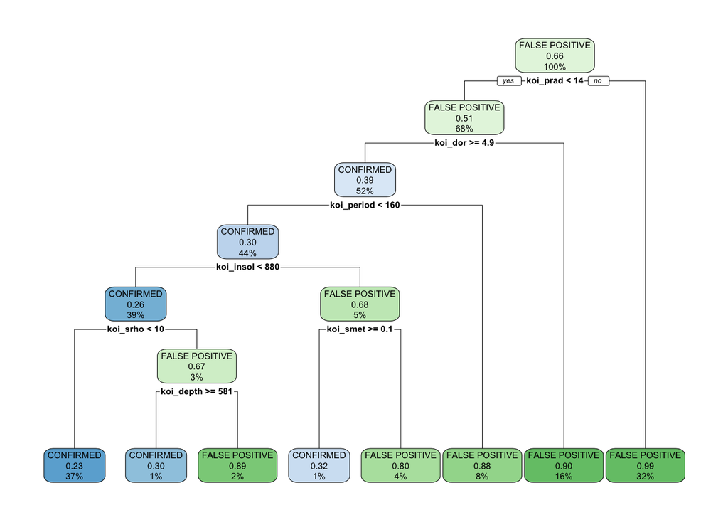

```
## Area under the curve: 0.8906
```

Our misclassification rate with this model is approximately 11.8%, which is lower than for our other models, so we would want to consider this model as the best option for our data if subsequent models do not yield a lower misclassification rate. Our ROC curve yields an AUC value of 0.8906.

### Random Forest

Lastly, we will use a random forest model.

```
##                 resp.test
## resp.prob.rf     CONFIRMED FALSE POSITIVE
##   CONFIRMED            414             60
##   FALSE POSITIVE        37            861
```

```
## [1] 0.07069971
```

```
## Area under the curve: 0.9264
```

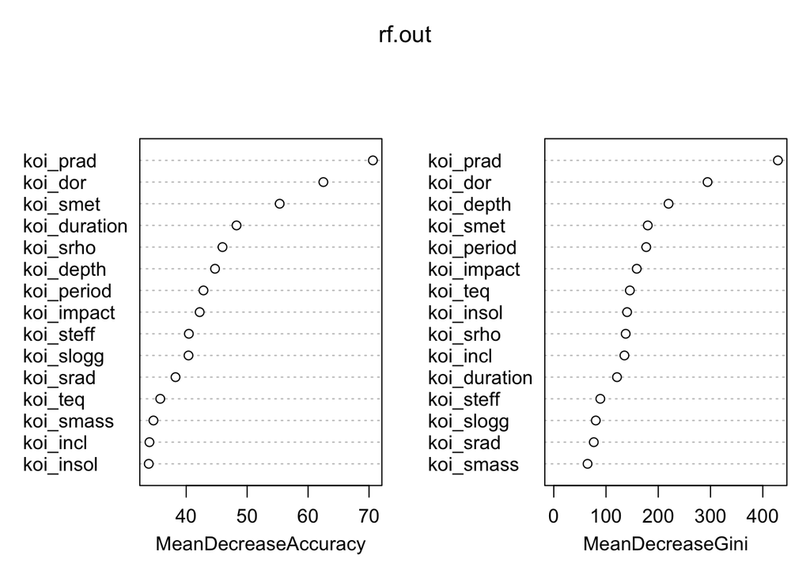

Upon a variable importance plot, we see that koi_prad and koi_dor seem to hold the highest amount of importance amongst the predictor variables.

We find that our misclassification rate is significantly lower than for all the other models, at 7.1%. In addition to this, we receive a fairly high AUC value of 0.9264.

### Naive Bayes

We may now attempt to use a Naive Bayes classifier on our data.

```
##                 resp.test
## resp.pred.naive  CONFIRMED FALSE POSITIVE
##   CONFIRMED            444            323
##   FALSE POSITIVE         7            598
```

```
## [1] 0.2405248
```

```
## Area under the curve: 0.8169
```

We receive a fairly higher MCR - 24.05% - than in other models we have observed, as well as a relatively lower AUC - 0.8169. So we will not be considering the Naive Bayes classifier for our data.

### XGBoost

We may now try to use the XGBoost algorithm.

```
## Area under the curve: 1
```

```
## [1] 0.001457726
```

Our XGBoost algorithm yields a very low MCR of 0.001 and an extremely high AUC value of 1. So we would consider this model to be the best option for predicting responses for our data.

Upon attempting ridge regression and lasso analyses, misclassification rates of 15% and 12% respectively were observed. Since these were both higher than for some of our other models, these models were discarded. Best subset selection was also considered, but due to the considerably large sample size of our data, it was too computationally inefficient to execute.

## Conclusion

After attempting to fit six potential models to our data, namely logistic regression, a classification tree, linear discriminant analysis, Naive Bayes, XGBoost, and random forest analysis, we found that using an XGBoost algorithm on our data yielded the lowest misclassification rate (as shown below). This suggests to us that an XGBoost model is likely the best possible option that would allow us to effectively categorize our exoplanetary candidates as either “CONFIRMED” or “FALSE POSITIVE”.

```
##                       Name.of.Model MCR.in.percent. AUC.in.percent.
## 1               Logistic Regression            12.2            94.1
## 2 Logistic Regression with PCA Data            22.8            85.0
## 3               Classification Tree            11.8            89.1
## 4                      LDA Analysis            17.2            81.9
## 5            Random Forest Analysis             7.1            92.6
## 6                       Naive Bayes            24.1            81.7
## 7                           XGBoost             0.1           100.0
```